# Reburns_Regen_analysis

# Effects of short-interval fires continue to accumulate, overwhelming the effects of local resiliency

This file includes code used to clean up, organize and analyze data on regeneration density and basal area of reburned plots in Interior Alaska. Raw data files are saved as "_raw.csv", as much work as possible is contained within the code itself.

# Density

## Data preparation

Density here is density of trees and seedlings on a scale of stems per hectare for each plot.

Code cleans up DBH, adds division (conifer / deciduous) to species, adds expansion factors specific to each plot (both dbh and seedlings were counted across different sub-samples for each plot, so scaling to ha is a bit more complicated).

```r
# dbh <- read.csv(here("data/dbh_raw.csv"))
#
#   # merging salix # so many willows, so little time
#   dbh$SPP[dbh$SPP == "SAGL"] <- "SALIX"
#   dbh$SPP[dbh$SPP == "SA_3"] <- "SALIX"
#   dbh$SPP[dbh$SPP == "SA_4"] <- "SALIX"
#   dbh$SPP[dbh$SPP == "SA_5"] <- "SALIX"
#   dbh$SPP[dbh$SPP == "SA_6"] <- "SALIX"
#   dbh$SPP[dbh$SPP == "SA_7"] <- "SALIX"
#   dbh$SPP[dbh$SPP == "SA_8"] <- "SALIX"
#   dbh$SPP[dbh$SPP == "SA_?"] <- "SALIX"
#   dbh$SPP[dbh$SPP == "SADE"] <- "SALIX"
#   dbh$SPP[dbh$SPP == "SAPU"] <- "SALIX"
#   dbh$SPP[dbh$SPP == "SAGL_R"] <- "SALIX"
#
#    # dropping unknown
#      dbh <- dbh %>%
#        filter(SPP != "UNKNOWN") # only a few unknown species present at Dalton site
#
#  # adding conifer and deciduous divisions
#     dbh$DIV[dbh$SPP == "PIME"] <- "c"
#     dbh$DIV[dbh$SPP == "BENE"] <- "d"
#     dbh$DIV[dbh$SPP == "POTR"] <- "d"
#     dbh$DIV[dbh$SPP == "POBA"] <- "d"
#     dbh$DIV[dbh$SPP == "SALIX"] <- "d"
#     dbh$DIV[dbh$SPP == "ARCTO"] <- "d"
#     dbh$DIV[dbh$SPP == "ALCR"] <- "d"
#
# # adding expansion factors
#     # assuming a plot is 1/25 of a ha, so half a plot is 1/50 of a ha.
#   dbh$EXP_FACT[dbh$QUAD == 2] <- 50
#   dbh$EXP_FACT[dbh$QUAD == 1] <- 100
#   dbh$EXP_FACT[dbh$QUAD == .1] <- 1000
#   dbh$EXP_FACT[dbh$QUAD == .2] <- 500
#
#  write.csv(dbh, here("data/dbh.csv"), row.names = F)
```

The next chunk brings in the altered dbh csv file, drops dead trees, sums the count of each species by plot and adds the division and expansion factors back in. The result is a object named “dens” containing densities of each plot according to species.

```r
dbh <- read.csv(here("data/dbh.csv"))

dbh$TREAT <- as.factor(dbh$TREAT)

  # dropping dead trees
    dbh <- dbh %>%
      filter(CANOPY > 0)
  # summing according to species
  dens <- dbh %>%
    group_by(SITE, TREAT, PLOT, SPP) %>%
    summarise(COUNT_PLOT = n()) %>%
    ungroup() %>%
    complete(nesting(SITE, TREAT, PLOT), SPP, fill = list(COUNT_PLOT = 0)) # adds zero-counts back in for species
  # adding divisions back in
    dens$DIV <- NA
    dens$DIV[dens$SPP == "PIME"] <- "c"
    dens$DIV[dens$SPP == "BENE"] <- "d"
    dens$DIV[dens$SPP == "POTR"] <- "d"
    dens$DIV[dens$SPP == "POBA"] <- "d"
    dens$DIV[dens$SPP == "SALIX"] <- "d"
    dens$DIV[dens$SPP == "ARCTO"] <- "d"
    dens$DIV[dens$SPP == "ALCR"] <- "d"
    dens$DIV <- as.factor(dens$DIV)

  # adding expansion factor back
    test <- dbh %>%
    group_by(SITE, TREAT, PLOT) %>%
    summarise(EXP_FACT = max(EXP_FACT)) %>%
      slice(rep(1:n(), each = 7)) %>% # 7 species at each plot, so each plot is 7 rows
      ungroup()
    dens$EXP_FACT <- test$EXP_FACT # adding expansion factors back in

# scaling up
    dens$COUNT_ha <- dens$COUNT_PLOT * dens$EXP_FACT

    rm(test, dbh)
```

### Describing the data

```r
head(dens)
```

```
## # A tibble: 6 x 8
##   SITE   TREAT PLOT  SPP   COUNT_PLOT DIV   EXP_FACT COUNT_ha
##   <chr>  <fct> <chr> <chr>      <dbl> <fct>    <int>    <dbl>
## 1 DALTON 0     10_0  ALCR           0 d           50        0
## 2 DALTON 0     10_0  ARCTO          0 d           50        0
## 3 DALTON 0     10_0  BENE           5 d           50      250
## 4 DALTON 0     10_0  PIME         112 c           50     5600
## 5 DALTON 0     10_0  POBA           0 d           50        0
## 6 DALTON 0     10_0  POTR           0 d           50        0
```

Column names:

**SITE** = the two sites used in this study. We’ve been referring to them as Dalton and Steese

- DALTON = upland site, located off Dalton Highway
- STEESE = lowland site, located off Steese Highway

**TREAT** = number of fires

- Can be 0, 1, 2 or 3
- treating as a factor at all times, not a continuous variable

**PLOT** = individual plot number

- name includes fire history
- 50 each of these, not in any particular order

**SPP** = species

- ALCR =
- ARTCO = dwarf birch
- BENE = betula neoalaskana, paper birch
- PIME = picea mariana, black spruce
- POBA
- POTR = populus tremuloides, quaking aspen
- SALIX = willow

**COUNT_PLOT** = number of trees per area sampled in plot

**DIV** = division

- conifer (c) vs deciduous (d)

**EXP_FACT** = expansion factor

- used because trees were not counted over the same area in each plot
- measure of how much a tree “makes up” (ie, 1 tree per 400m2 is how many trees per hectare?)

**COUNT_ha** = number of trees per hectare

The following code brings in the seedling data file, adds expansion factors specific to seedlings (since they were counted separately from dbh), scales seedling counts to stems/ha and combines the files of species dbh density and species seedling density. No white spruce existed above dbh height at any of the plots, but some seedlings occurred, so I also add a row of zero counts for white spruce to each dbh plot. The result from the entire code chunk is a object “dens” containing counts of seedlings and trees of each species for each plot, along with their respective expansion factors and counts per hectare.

```r
seed <- read.csv(here("data/seedling_count_raw.csv"))

# adding expansion factors
  seed$EXP_FACT <- NA
  seed$EXP_FACT[seed$M2 == 100] <- 100
  seed$EXP_FACT[seed$M2 == 10] <- 1000
  seed$EXP_FACT[seed$M2 == 20] <- 500
  seed$EXP_FACT[seed$M2 == 9] <- (10000/9)

# scaling up
  seed$COUNT_ha <- seed$EXP_FACT * seed$TOTAL_COUNT

# combining seedling and dbh
  seed <- seed %>%
    group_by(SITE, TREAT, PLOT) %>%
    arrange(match(SPP, c("ALCR", "ARCTO", "BENE", "POBA", "POTR", "SALIX", "PIGL", "PIME")),
            .by_group = T) # arranges species in the same order within plots
                           # also orders plots in same order within sites
                           # need to do to combine with dbh in a sec

  # creating PIGL rows
  # no white spruce at dbh height on plots, but need to add to combine with seedling file
  test <- dens %>%
    dplyr::select(SITE, TREAT, PLOT, EXP_FACT) %>% # need the dplyr because MASS package conflicts with select()
    distinct() # creates file where each row is a plot, maintains expansion factors/site/treat
  test$SPP <- as.factor("PIGL") # adds species
  test$COUNT_ha <- 0 # adds zero count
  test$COUNT_PLOT <- 0
  test$DIV <- as.factor("c")
  dens <- rbind(dens, test) # puts back into dbh file

   dens <- dens %>%
    group_by(SITE, TREAT, PLOT) %>% # same function as above # specifies order of species
    arrange(match(SPP, c("ALCR", "ARCTO", "BENE", "POBA", "POTR", "SALIX", "PIGL", "PIME")),
            .by_group = T) %>%
     rename(TREE_COUNT_PLOT = COUNT_PLOT, TREE_COUNT_HA = COUNT_ha,
            TREE_EXP_FACT = EXP_FACT) %>%
     ungroup()# renames tree counts so we can combine with seedling

  # combining files
  dens$SEED_COUNT_PLOT <- seed$TOTAL_COUNT
  dens$SEED_COUNT_HA <- seed$COUNT_ha
  dens$SEED_EXP_FACT <- seed$EXP_FACT

    # making sure number of fires is a factor
    dens$TREAT <- as.factor(dens$TREAT)

    # creating total count of both trees and seedlings
    dens$COUNT_HA <- dens$TREE_COUNT_HA + dens$SEED_COUNT_HA

 #  write.csv(dens, here("data/density.csv"), row.names = F)
    rm(test, seed)
```

Finally, this last chunk brings in the values of slope, solar radiation and elevation of each site, to be used as fixed effects in the later model.

```r
    # removing unburned sites
    dens <- dens[dens$TREAT !=0,]
    dens$TREAT <- as.factor(dens$TREAT)

    # looking at format of data, first three rows
    dens[1:3,]
```

```
## # A tibble: 3 x 12
##   SITE  TREAT PLOT  SPP   TREE_COUNT_PLOT DIV   TREE_EXP_FACT TREE_COUNT_HA
##   <chr> <fct> <chr> <chr>           <dbl> <fct>         <int>         <dbl>
## 1 DALT… 1     12_1  ALCR                2 d               500          1000
## 2 DALT… 1     12_1  ARCTO               0 d               500             0
## 3 DALT… 1     12_1  BENE               21 d               500         10500
## # … with 4 more variables: SEED_COUNT_PLOT <int>, SEED_COUNT_HA <dbl>,
## #   SEED_EXP_FACT <dbl>, COUNT_HA <dbl>
```

```r
# pulling in site attribute variables
    attrib <- read.csv(here("data/site_attrib.csv"))

    # no unburned sites used here
    attrib <-attrib[attrib$TREAT != 0,]

    # getting order of sites in dens
    order <- as.vector(unique(dens$PLOT)) # don't worry that its 42, remember this doesn't include unburned sites
    attrib <- attrib %>%
      group_by(SITE, TREAT) %>%
      arrange(match(PLOT,order)) %>% # matches the same order of plots as density file
      slice(rep(1:n(), each = 8)) # replicates each value by 8, since there's 8 rows per plot (8 species)
    # adding in attributes to density file
    dens$SLOPE <- attrib$SLOPE
    dens$ELEV <- attrib$ELEVATION
    dens$SOLAR <- attrib$SOLAR

    rm(attrib)
```

## Analysis

### Conifer

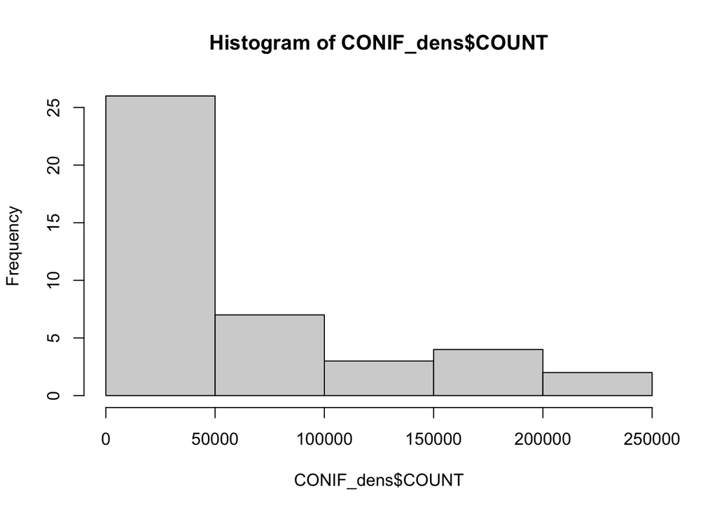

```r
CONIF_dens <- dens %>%
  group_by(SITE, TREAT, PLOT, DIV) %>%
    summarise(COUNT = sum(COUNT_HA), SLOPE = first(SLOPE)) %>%
    ungroup() %>%
    complete(nesting(SITE, TREAT, PLOT), DIV, fill = list(COUNT_HA = 0)) %>%
  filter(DIV == "c")
CONIF_dens$TREAT <- as.factor(CONIF_dens$TREAT) # just to make sure

  hist(CONIF_dens$COUNT)                                    #check
```

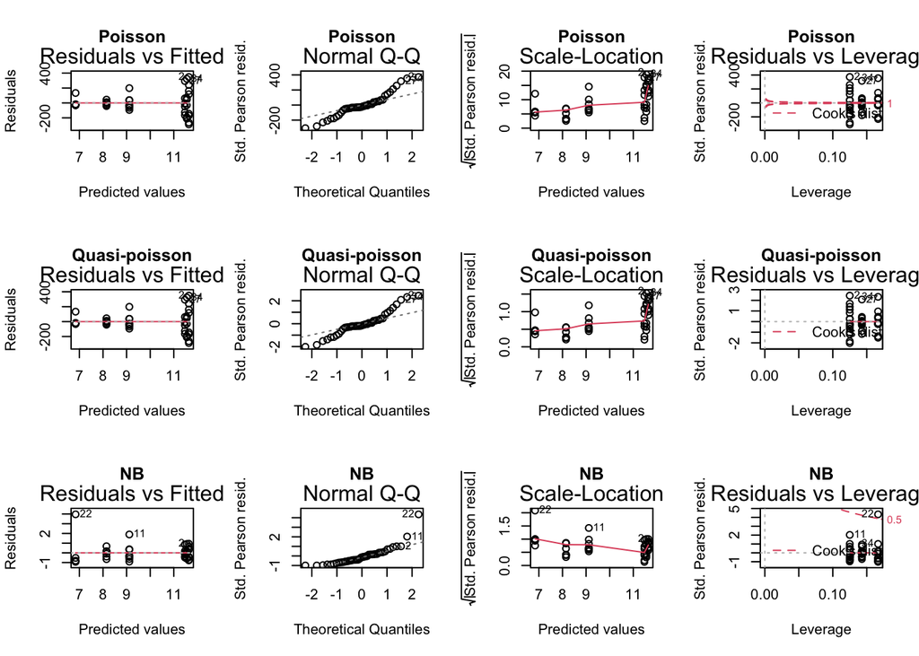

```r
  mC_D.nb <-    glm.nb(COUNT ~ TREAT + SITE + (TREAT*SITE), link = log, data = CONIF_dens)
  mC_D    <-    glm(COUNT ~ TREAT + SITE + (TREAT*SITE), family = poisson(link = "log"), data = CONIF_dens)
  mC_D_qp <-    glm(COUNT ~ TREAT + SITE + (TREAT*SITE), family = quasipoisson(link = "log"), data = CONIF_dens)

  # residuals
  par(mfrow=c(3,4))
  plot(mC_D, main="Poisson")
  plot(mC_D_qp, main="Quasi-poisson")
  plot(mC_D.nb, main="NB")
```

```r
  # parameters
  summary(mC_D)
```

```
##
## Call:
## glm(formula = COUNT ~ TREAT + SITE + (TREAT * SITE), family = poisson(link = "log"),
##     data = CONIF_dens)
##
## Deviance Residuals:
##     Min       1Q   Median       3Q      Max
## -360.09   -49.28   -23.32    42.78   304.51
##
## Coefficients:
##                    Estimate Std. Error  z value            Pr(>|z|)
## (Intercept)       11.635972   0.001051 11067.94 <0.0000000000000002 ***
## TREAT2            -2.520630   0.003854  -654.08 <0.0000000000000002 ***
## TREAT3            -4.797210   0.013404  -357.90 <0.0000000000000002 ***
## SITESTEESE        -0.165954   0.001611  -102.99 <0.0000000000000002 ***
## TREAT2:SITESTEESE  2.599789   0.004237   613.64 <0.0000000000000002 ***
## TREAT3:SITESTEESE  1.475390   0.014916    98.92 <0.0000000000000002 ***
## ---
## Signif. codes:  0 '***' 0.001 '**' 0.01 '*' 0.05 '.' 0.1 ' ' 1
##
## (Dispersion parameter for poisson family taken to be 1)
##
##     Null deviance: 3278435  on 41  degrees of freedom
## Residual deviance:  862305  on 36  degrees of freedom
## AIC: 862777
##
## Number of Fisher Scoring iterations: 6
```

```r
  summary(mC_D_qp)
```

```
##
## Call:
## glm(formula = COUNT ~ TREAT + SITE + (TREAT * SITE), family = quasipoisson(link = "log"),
##     data = CONIF_dens)
##
## Deviance Residuals:
##     Min       1Q   Median       3Q      Max
## -360.09   -49.28   -23.32    42.78   304.51
##
## Coefficients:
##                   Estimate Std. Error t value             Pr(>|t|)
## (Intercept)        11.6360     0.1599  72.780 < 0.0000000000000002 ***
## TREAT2             -2.5206     0.5861  -4.301             0.000124 ***
## TREAT3             -4.7972     2.0384  -2.353             0.024182 *
## SITESTEESE         -0.1660     0.2450  -0.677             0.502586
## TREAT2:SITESTEESE   2.5998     0.6443   4.035             0.000272 ***
## TREAT3:SITESTEESE   1.4754     2.2683   0.650             0.519539
## ---
## Signif. codes:  0 '***' 0.001 '**' 0.01 '*' 0.05 '.' 0.1 ' ' 1
##
## (Dispersion parameter for quasipoisson family taken to be 23126.73)
##
##     Null deviance: 3278435  on 41  degrees of freedom
## Residual deviance:  862305  on 36  degrees of freedom
## AIC: NA
##
## Number of Fisher Scoring iterations: 6
```

```r
  summary(mC_D.nb) # AIC 924
```

```
##
## Call:
## glm.nb(formula = COUNT ~ TREAT + SITE + (TREAT * SITE), data = CONIF_dens,
##     link = log, init.theta = 0.8298936632)
##
## Deviance Residuals:
##     Min       1Q   Median       3Q      Max
## -3.4149  -0.7060  -0.1231   0.2556   2.1080
##
## Coefficients:
##                   Estimate Std. Error z value             Pr(>|z|)
## (Intercept)        11.6360     0.3881  29.982 < 0.0000000000000002 ***
## TREAT2             -2.5206     0.5489  -4.592 0.000004381804737570 ***
## TREAT3             -4.7972     0.5930  -8.090 0.000000000000000597 ***
## SITESTEESE         -0.1660     0.5681  -0.292              0.77020
## TREAT2:SITESTEESE   2.5998     0.8211   3.166              0.00154 **
## TREAT3:SITESTEESE   1.4754     0.8342   1.769              0.07697 .
## ---
## Signif. codes:  0 '***' 0.001 '**' 0.01 '*' 0.05 '.' 0.1 ' ' 1
##
## (Dispersion parameter for Negative Binomial(0.8299) family taken to be 1)
##
##     Null deviance: 124.56  on 41  degrees of freedom
## Residual deviance:  50.56  on 36  degrees of freedom
## AIC: 924.43
##
## Number of Fisher Scoring iterations: 1
##
##
##               Theta:  0.830
##           Std. Err.:  0.166
##
##  2 x log-likelihood:  -910.430
```

```r
  #note the prediction vs. observed isn't great, but that's not the point here
  dev.off()
```

```r
  plot(predict(mC_D.nb, type="response",se.fit=T)$fit,CONIF_dens$COUNT) #plots the exponentiated prediction back
  abline(0,1, col="red")                                #one to one line

  #the model doesn't do bad at predicting areas with zero trees (treatment effect) are zero, it's the variability
  #in the regen where there is regen (treatments 1 and 2 primarily) that must be explained by other factors.
  #That's clear from this prediction plot and where the major errors are, but also in the standard errors.

  plot(predict(mC_D.nb, type="response",se.fit=T)$fit, predict(mC_D.nb, type="response",se.fit=T)$se.fit, ylab="SE", xlab="Prediction")
  abline(0,1, col="red")

  #bringing in other covariates

  #to do so, adding them into the glm above, but then check the diagnostics again of course
    mC_D.nb <-  glm.nb(COUNT ~ TREAT + SITE + (TREAT*SITE), link = log, data = CONIF_dens)
    mC_D.nb.slope <-    glm.nb(COUNT ~ TREAT + SITE + SLOPE  + (TREAT*SITE),
                             link = log, data = CONIF_dens)

    par(mfrow=c(2,4))
    plot(mC_D.nb, main="NB")
    plot(mC_D.nb.slope, main="Slope")

  summary(mC_D.nb) # AIC 924
```

```
##
## Call:
## glm.nb(formula = COUNT ~ TREAT + SITE + (TREAT * SITE), data = CONIF_dens,
##     link = log, init.theta = 0.8298936632)
##
## Deviance Residuals:
##     Min       1Q   Median       3Q      Max
## -3.4149  -0.7060  -0.1231   0.2556   2.1080
##
## Coefficients:
##                   Estimate Std. Error z value             Pr(>|z|)
## (Intercept)        11.6360     0.3881  29.982 < 0.0000000000000002 ***
## TREAT2             -2.5206     0.5489  -4.592 0.000004381804737570 ***
## TREAT3             -4.7972     0.5930  -8.090 0.000000000000000597 ***
## SITESTEESE         -0.1660     0.5681  -0.292              0.77020
## TREAT2:SITESTEESE   2.5998     0.8211   3.166              0.00154 **
## TREAT3:SITESTEESE   1.4754     0.8342   1.769              0.07697 .
## ---
## Signif. codes:  0 '***' 0.001 '**' 0.01 '*' 0.05 '.' 0.1 ' ' 1
##
## (Dispersion parameter for Negative Binomial(0.8299) family taken to be 1)
##
##     Null deviance: 124.56  on 41  degrees of freedom
## Residual deviance:  50.56  on 36  degrees of freedom
## AIC: 924.43
##
## Number of Fisher Scoring iterations: 1
##
##
##               Theta:  0.830
##           Std. Err.:  0.166
##
##  2 x log-likelihood:  -910.430
```

```r
  summary(mC_D.nb.slope) # AIC 926
```

```
##
## Call:
## glm.nb(formula = COUNT ~ TREAT + SITE + SLOPE + (TREAT * SITE),
##     data = CONIF_dens, link = log, init.theta = 0.8303218153)
##
## Deviance Residuals:
##     Min       1Q   Median       3Q      Max
## -3.4196  -0.7133  -0.1226   0.2643   2.1130
##
## Coefficients:
##                   Estimate Std. Error z value             Pr(>|z|)
## (Intercept)       11.50296    0.93634  12.285 < 0.0000000000000002 ***
## TREAT2            -2.46626    0.60151  -4.100     0.00004130001317 ***
## TREAT3            -4.82857    0.68803  -7.018     0.00000000000225 ***
## SITESTEESE        -0.06207    0.86117  -0.072              0.94254
## SLOPE              0.01747    0.12426   0.141              0.88820
## TREAT2:SITESTEESE  2.56355    0.83174   3.082              0.00206 **
## TREAT3:SITESTEESE  1.52162    0.94819   1.605              0.10855
## ---
## Signif. codes:  0 '***' 0.001 '**' 0.01 '*' 0.05 '.' 0.1 ' ' 1
##
## (Dispersion parameter for Negative Binomial(0.8303) family taken to be 1)
##
##     Null deviance: 124.621  on 41  degrees of freedom
## Residual deviance:  50.559  on 35  degrees of freedom
## AIC: 926.4
##
## Number of Fisher Scoring iterations: 1
##
##
##               Theta:  0.830
##           Std. Err.:  0.166
##
##  2 x log-likelihood:  -910.404
```

```r
  round(confint(mC_D.nb), digits = 2)
```

```
##                   2.5 % 97.5 %
## (Intercept)       10.96  12.51
## TREAT2            -3.62  -1.42
## TREAT3            -5.96  -3.57
## SITESTEESE        -1.29   0.99
## TREAT2:SITESTEESE  0.98   4.24
## TREAT3:SITESTEESE -0.20   3.12
```

```r
  sqrt(mean(mC_D.nb$residuals^2))
```

```
## [1] 0.9482172
```

```r
  sqrt(mean(mC_D.nb.slope$residuals^2))
```

```
## [1] 0.947998
```

### Deciduous

The next piece of code conducts the same process, but for deciduous density.

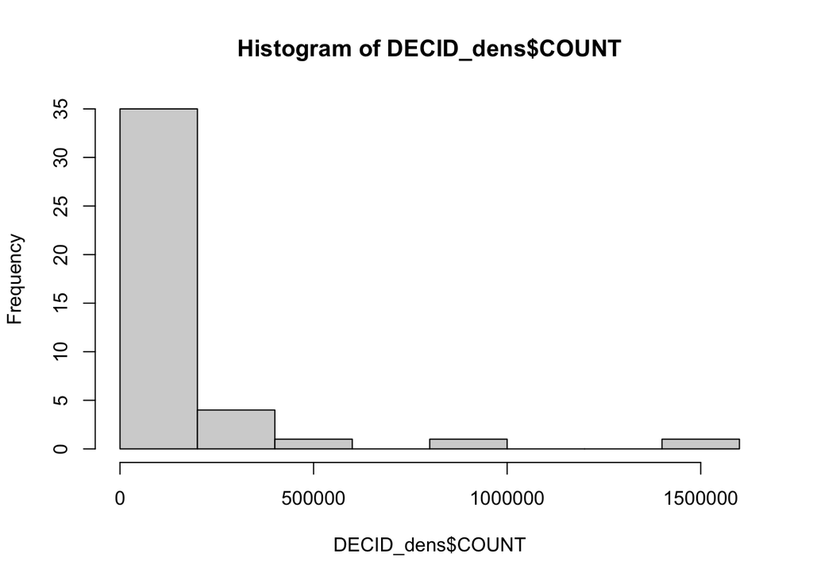

```r
DECID_dens <- dens %>%
  group_by(SITE, TREAT, PLOT, DIV) %>%
    summarise(COUNT = sum(COUNT_HA), SLOPE = first(SLOPE)) %>%
    ungroup() %>%
    complete(nesting(SITE, TREAT, PLOT), DIV, fill = list(COUNT_HA = 0)) %>%
  filter(DIV == "d")
  hist(DECID_dens$COUNT)                                    #check
```

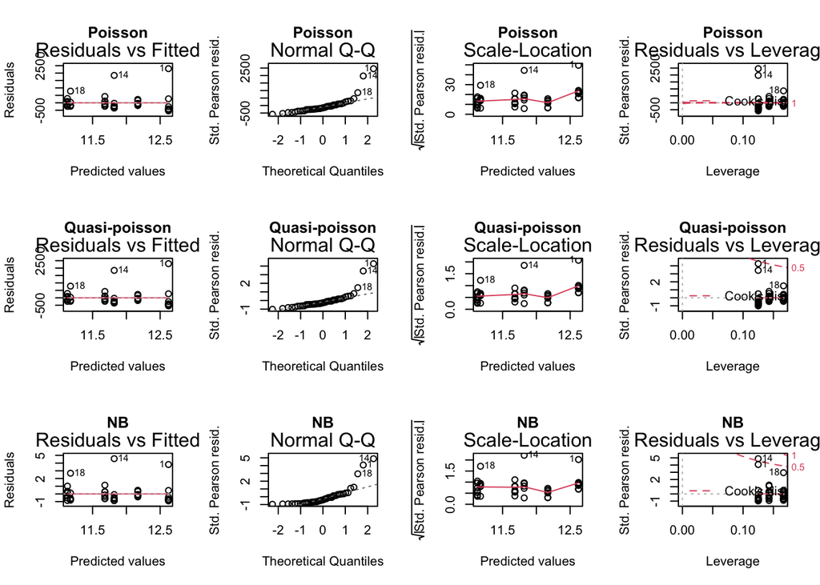

```r
  mD_D.nb <-    glm.nb(COUNT ~ TREAT + SITE + (TREAT*SITE), link = log, data = DECID_dens)
  mD_D <-       glm(COUNT ~ TREAT + SITE + (TREAT*SITE), family = poisson(link = "log"), data = DECID_dens)
  mD_D.qp <-    glm(COUNT ~ TREAT + SITE + (TREAT*SITE), family = quasipoisson(link = "log"), data = DECID_dens)

  # residuals
  par(mfrow=c(3,4))
  plot(mD_D, main="Poisson")
  plot(mD_D.qp, main="Quasi-poisson")
  plot(mD_D.nb, main="NB")
```

```r
  sqrt(mean(mD_D.nb$residuals^2))
```

```
## [1] 1.270167
```

```r
  sqrt(mean(mD_D$residuals^2))
```

```
## [1] 1.270167
```

```r
  sqrt(mean(mD_D.qp$residuals^2))
```

```
## [1] 1.270167
```

```r
  # parameters
  summary(mD_D)
```

```
##
## Call:
## glm(formula = COUNT ~ TREAT + SITE + (TREAT * SITE), family = poisson(link = "log"),
##     data = DECID_dens)
##
## Deviance Residuals:
##     Min       1Q   Median       3Q      Max
## -757.84  -300.32  -154.81    79.34  1620.30
##
## Coefficients:
##                     Estimate Std. Error z value            Pr(>|z|)
## (Intercept)       12.6233016  0.0006417 19671.3 <0.0000000000000002 ***
## TREAT2            -0.8032592  0.0011538  -696.2 <0.0000000000000002 ***
## TREAT3            -1.4495855  0.0016588  -873.9 <0.0000000000000002 ***
## SITESTEESE        -1.4950937  0.0015845  -943.6 <0.0000000000000002 ***
## TREAT2:SITESTEESE  1.8442438  0.0020724   889.9 <0.0000000000000002 ***
## TREAT3:SITESTEESE  2.0036238  0.0024610   814.2 <0.0000000000000002 ***
## ---
## Signif. codes:  0 '***' 0.001 '**' 0.01 '*' 0.05 '.' 0.1 ' ' 1
##
## (Dispersion parameter for poisson family taken to be 1)
##
##     Null deviance: 10083609  on 41  degrees of freedom
## Residual deviance:  8287764  on 36  degrees of freedom
## AIC: 8288318
##
## Number of Fisher Scoring iterations: 6
```

```r
  summary(mD_D.qp)
```

```
##
## Call:
## glm(formula = COUNT ~ TREAT + SITE + (TREAT * SITE), family = quasipoisson(link = "log"),
##     data = DECID_dens)
##
## Deviance Residuals:
##     Min       1Q   Median       3Q      Max
## -757.84  -300.32  -154.81    79.34  1620.30
##
## Coefficients:
##                   Estimate Std. Error t value            Pr(>|t|)
## (Intercept)        12.6233     0.3688  34.225 <0.0000000000000002 ***
## TREAT2             -0.8033     0.6632  -1.211               0.234
## TREAT3             -1.4496     0.9534  -1.520               0.137
## SITESTEESE         -1.4951     0.9107  -1.642               0.109
## TREAT2:SITESTEESE   1.8442     1.1911   1.548               0.130
## TREAT3:SITESTEESE   2.0036     1.4145   1.417               0.165
## ---
## Signif. codes:  0 '***' 0.001 '**' 0.01 '*' 0.05 '.' 0.1 ' ' 1
##
## (Dispersion parameter for quasipoisson family taken to be 330347.2)
##
##     Null deviance: 10083609  on 41  degrees of freedom
## Residual deviance:  8287764  on 36  degrees of freedom
## AIC: NA
##
## Number of Fisher Scoring iterations: 6
```

```r
  summary(mD_D.nb) # AIC 1087
```

```
##
## Call:
## glm.nb(formula = COUNT ~ TREAT + SITE + (TREAT * SITE), data = DECID_dens,
##     link = log, init.theta = 0.8361786282)
##
## Deviance Residuals:
##     Min       1Q   Median       3Q      Max
## -2.4741  -1.0760  -0.4356   0.2287   2.3167
##
## Coefficients:
##                   Estimate Std. Error z value             Pr(>|z|)
## (Intercept)        12.6233     0.3866  32.649 < 0.0000000000000002 ***
## TREAT2             -0.8033     0.5468  -1.469              0.14182
## TREAT3             -1.4496     0.5906  -2.454              0.01411 *
## SITESTEESE         -1.4951     0.5660  -2.642              0.00825 **
## TREAT2:SITESTEESE   1.8442     0.8180   2.255              0.02416 *
## TREAT3:SITESTEESE   2.0036     0.8310   2.411              0.01590 *
## ---
## Signif. codes:  0 '***' 0.001 '**' 0.01 '*' 0.05 '.' 0.1 ' ' 1
##
## (Dispersion parameter for Negative Binomial(0.8362) family taken to be 1)
##
##     Null deviance: 59.588  on 41  degrees of freedom
## Residual deviance: 49.566  on 36  degrees of freedom
## AIC: 1087.6
##
## Number of Fisher Scoring iterations: 1
##
##
##               Theta:  0.836
##           Std. Err.:  0.158
##
##  2 x log-likelihood:  -1073.614
```

```r
  dev.off()
```

```r
  plot(predict(mD_D.nb, type="response",se.fit=T)$fit,DECID_dens$COUNT) #plots the exponentiated prediction back
  abline(0,1, col="red")                                #one to one line

  plot(predict(mD_D.nb, type="response",se.fit=T)$fit,
       predict(mD_D.nb, type="response",se.fit=T)$se.fit, ylab="SE", xlab="Prediction")

  #bringing in other covariates
  #adding them into the glm above
  mD_D.nb <-    glm.nb(COUNT ~ TREAT + SITE + (TREAT*SITE), link = log, data = DECID_dens)
  mD_D.nb.slope <-  glm.nb(COUNT ~ TREAT + SITE + SLOPE + (TREAT*SITE),link = log, data = DECID_dens)

  dev.off()
```

```r
  par(mfrow=c(5,4))
  plot(mD_D.nb, main="NB")
  plot(mD_D.nb.slope, main="Slope")

  summary(mD_D.nb) # AIC 1087
```

```
##
## Call:
## glm.nb(formula = COUNT ~ TREAT + SITE + (TREAT * SITE), data = DECID_dens,
##     link = log, init.theta = 0.8361786282)
##
## Deviance Residuals:
##     Min       1Q   Median       3Q      Max
## -2.4741  -1.0760  -0.4356   0.2287   2.3167
##
## Coefficients:
##                   Estimate Std. Error z value             Pr(>|z|)
## (Intercept)        12.6233     0.3866  32.649 < 0.0000000000000002 ***
## TREAT2             -0.8033     0.5468  -1.469              0.14182
## TREAT3             -1.4496     0.5906  -2.454              0.01411 *
## SITESTEESE         -1.4951     0.5660  -2.642              0.00825 **
## TREAT2:SITESTEESE   1.8442     0.8180   2.255              0.02416 *
## TREAT3:SITESTEESE   2.0036     0.8310   2.411              0.01590 *
## ---
## Signif. codes:  0 '***' 0.001 '**' 0.01 '*' 0.05 '.' 0.1 ' ' 1
##
## (Dispersion parameter for Negative Binomial(0.8362) family taken to be 1)
##
##     Null deviance: 59.588  on 41  degrees of freedom
## Residual deviance: 49.566  on 36  degrees of freedom
## AIC: 1087.6
##
## Number of Fisher Scoring iterations: 1
##
##
##               Theta:  0.836
##           Std. Err.:  0.158
##
##  2 x log-likelihood:  -1073.614
```

```r
  summary(mD_D.nb.slope) # AIC 1089
```

```
##
## Call:
## glm.nb(formula = COUNT ~ TREAT + SITE + SLOPE + (TREAT * SITE),
##     data = DECID_dens, link = log, init.theta = 0.8362198043)
##
## Deviance Residuals:
##     Min       1Q   Median       3Q      Max
## -2.4691  -1.0735  -0.4344   0.2293   2.3183
##
## Coefficients:
##                    Estimate Std. Error z value            Pr(>|z|)
## (Intercept)       12.557883   0.932988  13.460 <0.0000000000000002 ***
## TREAT2            -0.780368   0.599372  -1.302              0.1929
## TREAT3            -1.484658   0.685458  -2.166              0.0303 *
## SITESTEESE        -1.444573   0.858103  -1.683              0.0923 .
## SLOPE              0.009568   0.123809   0.077              0.9384
## TREAT2:SITESTEESE  1.829301   0.828790   2.207              0.0273 *
## TREAT3:SITESTEESE  2.046331   0.944717   2.166              0.0303 *
## ---
## Signif. codes:  0 '***' 0.001 '**' 0.01 '*' 0.05 '.' 0.1 ' ' 1
##
## (Dispersion parameter for Negative Binomial(0.8362) family taken to be 1)
##
##     Null deviance: 59.591  on 41  degrees of freedom
## Residual deviance: 49.566  on 35  degrees of freedom
## AIC: 1089.6
##
## Number of Fisher Scoring iterations: 1
##
##
##               Theta:  0.836
##           Std. Err.:  0.158
##
##  2 x log-likelihood:  -1073.611
```

```r
  round(confint(mD_D.nb), digits = 2)
```

```
##                   2.5 % 97.5 %
## (Intercept)       11.95  13.49
## TREAT2            -1.90   0.29
## TREAT3            -2.61  -0.23
## SITESTEESE        -2.62  -0.34
## TREAT2:SITESTEESE  0.23   3.48
## TREAT3:SITESTEESE  0.34   3.64
```

```r
  sqrt(mean(mD_D.nb$residuals^2))
```

```
## [1] 1.270167
```

```r
  sqrt(mean(mD_D.nb.slope$residuals^2))
```

```
## [1] 1.270251
```

## Values for text

Finally, the code below pulls out specific values of density used in the text of the manuscript.

```r
# getting values
dens <- read.csv(here("data/density.csv"))

treat_dens <- dens %>%
  group_by(SITE, TREAT, DIV) %>%
  summarise(AV = mean(COUNT_HA), SE = se(COUNT_HA))
treat_dens$SE <- round(treat_dens$SE, digits = 0)
treat_dens$AV <- round(treat_dens$AV, digits = 0)

treat_dens %>%
  filter(SITE == "DALTON") %>%
  filter(DIV == "c")
```

```
## # A tibble: 4 x 5
## # Groups:   SITE, TREAT [4]
##   SITE   TREAT DIV      AV    SE
##   <chr>  <int> <chr> <dbl> <dbl>
## 1 DALTON     0 c      6681  2676
## 2 DALTON     1 c     56547 20270
## 3 DALTON     2 c      4547  1443
## 4 DALTON     3 c       467   413
```

```r
stee_con_dens <- treat_dens %>%
  filter(SITE == "STEESE") %>%
  filter(DIV == "c")

treat_dens %>%
  filter(SITE == "DALTON") %>%
  filter(DIV == "d")
```

```
## # A tibble: 4 x 5
## # Groups:   SITE, TREAT [4]
##   SITE   TREAT DIV      AV    SE
##   <chr>  <int> <chr> <dbl> <dbl>
## 1 DALTON     0 d       308   141
## 2 DALTON     1 d     50592 23905
## 3 DALTON     2 d     22658 15122
## 4 DALTON     3 d     11872  7466
```

```r
treat_dens %>%
  filter(SITE == "STEESE") %>%
  filter(DIV == "d")
```

```
## # A tibble: 4 x 5
## # Groups:   SITE, TREAT [4]
##   SITE   TREAT DIV      AV    SE
##   <chr>  <int> <chr> <dbl> <dbl>
## 1 STEESE     0 d        59    46
## 2 STEESE     1 d     11344  3817
## 3 STEESE     2 d     32126 10176
## 4 STEESE     3 d     19742  6578
```

# Basal Area

## Data Preparation

The code below brings in “ba.csv”, removes unburned sites, creates the DECID_BA object (which contains just deciduous basal area) and recalculates basal area per hectare. It then brings the site_attrib file back in and adds the values of slope, elevation and solar radiation of each plot into the deciduous basal area object.

```r
# bringing in data
  ba <- read.csv(here("data/ba.csv"), stringsAsFactors = F)

  # removing unburned sites
  ba <- ba[ba$TREAT != 0,]

  # looking at format of data, first three rows
  ba[1:3,]
```

```
##     SITE PLOT TREAT   SPP DBH CANOPY BROWSE  UND START_END CLUMP QUAD DIV
## 1 DALTON 32_2     2 SALIX 1.0     60      y VAVI     START CLUMP  100   d
## 2 DALTON 32_2     2 SALIX 0.5     25      n VAVI           CLUMP  100   d
## 3 DALTON 32_2     2 SALIX 0.5     70      n VAVI           CLUMP  100   d
##   BA_unscale       BA_ha
## 1  0.0000785 0.007853982
## 2  0.0000196 0.001963495
## 3  0.0000196 0.001963495
```

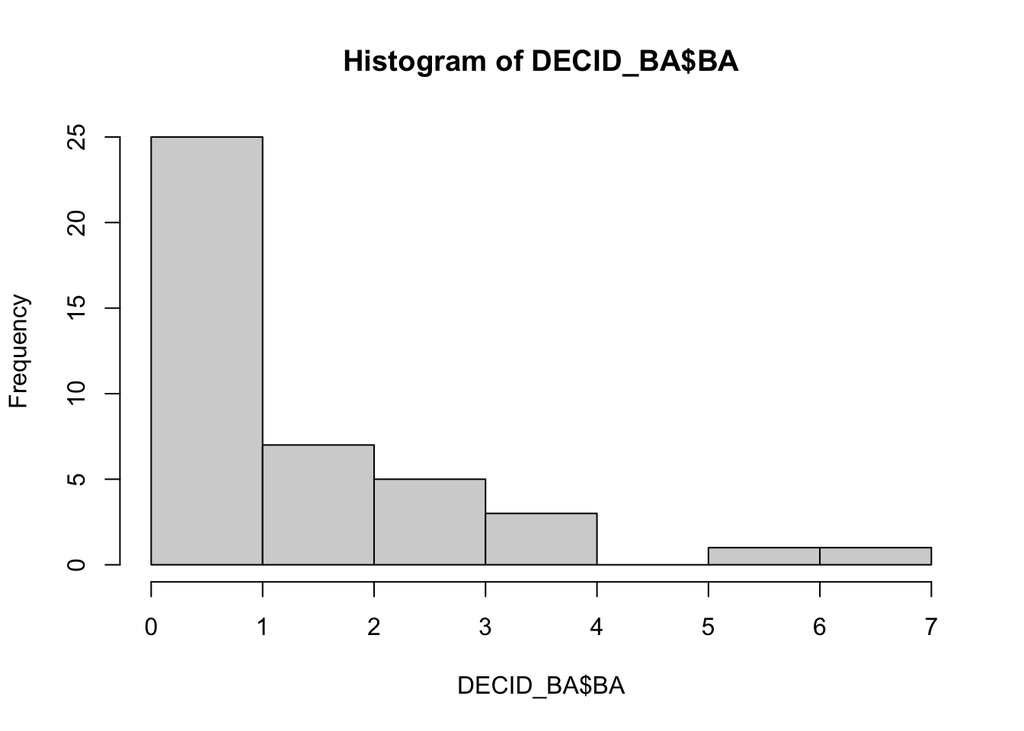

```r
   DECID_BA <- subset(ba, ba$DIV == "d")

  DECID_BA$QUAD[DECID_BA$QUAD == 2] <- 50   #assuming a plot is 1/25 of a ha, so half a plot is 1/50 of a ha.
  DECID_BA$QUAD[DECID_BA$QUAD == 1] <- 100
  DECID_BA$QUAD[DECID_BA$QUAD == .1] <- 1000
  DECID_BA$QUAD[DECID_BA$QUAD == .2] <- 500

  #calc basal area
  DECID_BA$BA <- (pi * (DECID_BA$DBH/2)^2)/10000    #convert to ba and cm2 to m2. Just pi*r2
  DECID_BA$BA_ha <- DECID_BA$BA * DECID_BA$QUAD     #multiply by expansion factor

DECID_BA <- DECID_BA %>%
    group_by(SITE, TREAT, PLOT, DIV) %>%
    summarise(BA = sum(BA_ha))
  #histogram
  hist(DECID_BA$BA)
```

```r
  # pulling in site attribute variables
    attrib <- read.csv(here("data/site_attrib.csv"))

    # no unburned
    attrib <-attrib[attrib$TREAT != 0,]

    # getting order of sites in dens
    order <- as.vector(DECID_BA$PLOT) # don't worry that its 42, remember this doesnt include unburned
    attrib <- attrib %>%
      group_by(SITE, TREAT) %>%
      arrange(match(PLOT,order))
    # adding in attributes to density file
    DECID_BA$SLOPE <- attrib$SLOPE
    DECID_BA$ELEV <- attrib$ELEVATION
    DECID_BA$SOLAR <- attrib$SOLAR

    rm(attrib)
```